# Taller 8: Operaciones espaciales con datos raster {terra}

Uso Avanzado de Sistemas de Información Geográfica

Autor/a

Afiliación

Dr. Francisco Zambrano

Escuela de Ingeniería en Medio Ambiente, Universidad Mayor

Fecha de publicación

28 de octubre de 2024

# 1 Descripción

En la primera parte del curso se familiarizó con R [@R2023], las principales estructuras de datos, como realizar indexación, conoció algunas funciones y pudo realizar algunos gráficos básicos; utilizando R base. Ahora, en el curso hemos empezado a trabajar en R con datos geoespaciales de tipo vectoriales y raster. Para manejar datos vectoriales utilizamos `{sf}` y para datos de tipo raster `{terra}`. En el taller anterior trabajo realizando operaciones geométricas con datos vectoriales. En este taller trabajaremos con operaciones espaciales con datos raster utilizando la libreria `{terra}`.

# 2 Objetivo del taller

Manejar operaciones espaciales con datos raster utilizando la libreria `{terra}`.

# 3 Instalar y cargar {terra}

Hasta el momento en el curso hemos trabajado con los paquetes que vienen inculidos en R base (stats, graphics, grDevices, utils, datasets, methods y base). Ahora empezaremos a trabajar con paquetes adicionales que no vienen instalados por defecto en `R`, por lo que deberá instalarlos y cargarlos en R. En este taller trabajaremos con `{terra}` para poder manejar datos espaciales rasters.

Para instala y cargar `{terra}` debe realizar lo siguiente:

**Código**

```r
# instala {terra}
install.packages('terra')

# cargar {terra} en el entorno de R para poder utilizar
# las funciones adicionales para manejo de datos vectoriales que contiene

library(terra)
```

# 4 Data

Para este taller se trabajará con los siguientes datos raster

- `dem_chile.tif` : datos de elevación para chile
- `temp_chile.tif`: datos de temperatura promedio mensual para chile (1990-2020). Tiene 12 capas que corresponden a los meses del año, cada capa corresponde al promedio de temperatura para 1990-2020 de la temperatura para cada mes (enero a diciembre).
- `prec_chile.tif:` datos de precipitación acumulada mensual para chile (1990-2020). Tiene 12 capas que corresponden a los meses del año, cada capa corresponde a la precipitación acumualda mensual promedio para 1990-2020 (enero a diciembre).

Descargar desde [acá](https://drive.google.com/drive/folders/1gXapUcoHkQxNBm0-WDBpmZxmMGSnbRob?usp=sharing)

# 5 ¿Qué debe entregar?

Deberá utilizar RStudio para crear un script, en donde resolverá cada uno de los ejercicios. Debe utilizar los comentarios (`#`) para hacer una descripción del ejercicio e incorporar cualquier información que ayude a entender lo realizado. A modo de ejemplo:

**Código**

```r
# Ejercicio 1:
# comentario explicando lo que se hace
{
 Acá va el script que resuelve el ejericio 1

}
```

Debe guardar el script con el nombre `taller8.R`. Los archivos los debe subir en el campus virtual en la sección `Actividades -> Evaluaciones -> Talleres -> Taller5`

# 6 Fecha de entrega

Lunes 28 de octubre hasta las 23:59pm

# 7 Ejercicios

1. Cree una capa raster de mascara respecto a la extensión definida por:
- longitud entre `72°53' 4"O` y `71°0'26"O`
- latitudes `37° 11' 51"S` y `36° 0' 20"`

**Código**

```r
library(terra)
```

**Código**

```r
dem <- rast('../data/capas_raster/dem_chile.tif')
rmask <- rast(xmin = -72.88441,ymin=-37.19762,xmax=-71.00730,ymax=-36.00556)
values(rmask) <- 1:ncell(rmask)
```

2. Aplique la mascara anterior a los raster de elevación, precipitación y temperatura.

**Código**

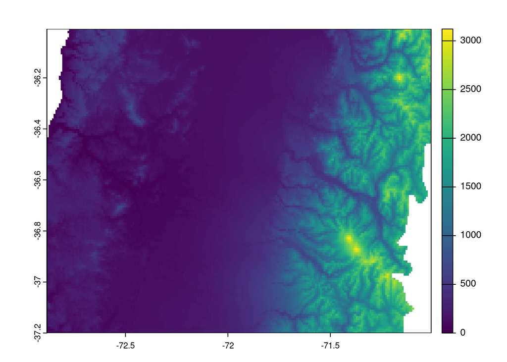

```r
temp <- rast('../data/capas_raster/temp_chile.tif')
pre <- rast('../data/capas_raster/prec_chile.tif')
dem_m <- dem[rmask,drop = FALSE]
temp_m <- crop(temp,rmask)
pre_m <- crop(pre,rmask)
plot(dem_m)
```

**Código**

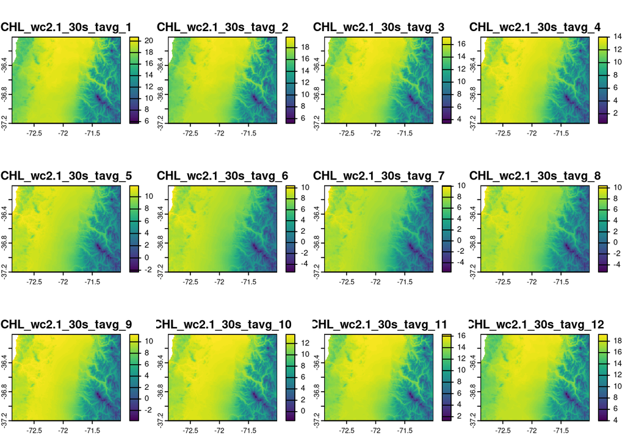

```r
plot(temp_m)
```

**Código**

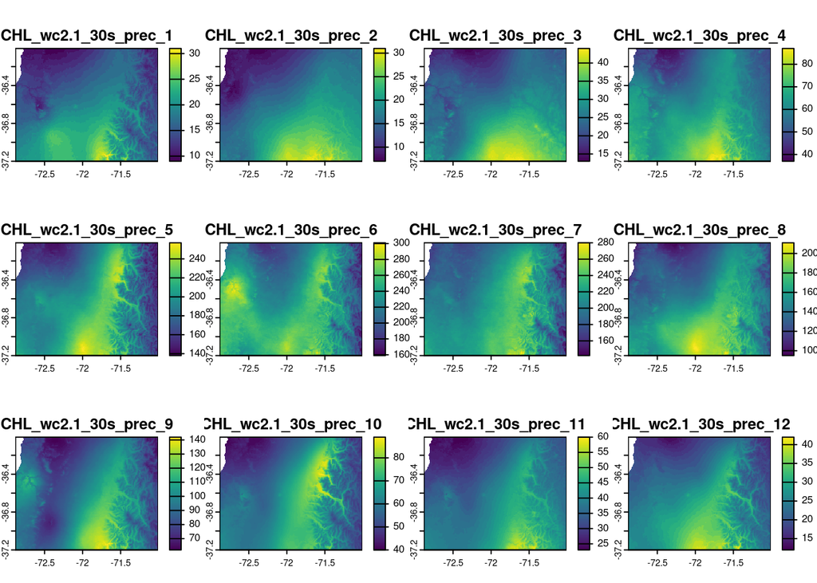

```r
plot(pre_m)
```

3. Calcule la temperatura promedio anual y la precipitación acumulada anual, para los raster enmascarados de la pregunta anterior.

**Código**

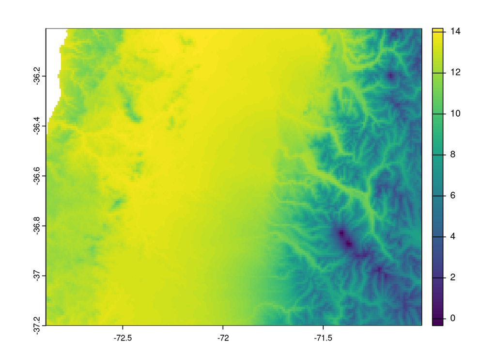

```r
temp_avg <- mean(temp_m)
pre_acu <- sum(pre_m)
plot(temp_avg)
```

**Código**

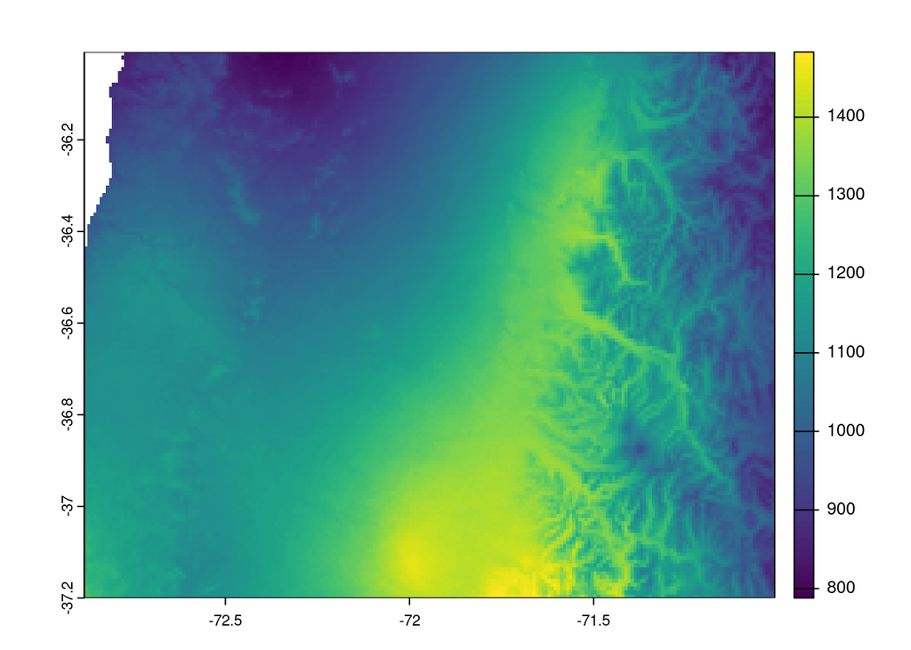

```r
plot(pre_acu)
```

4. Utilizando el raster de elevación enmascarado para la extensión dada, cree una nueva mascara que considere las elevaciones entre 100 y 1500m

**Código**

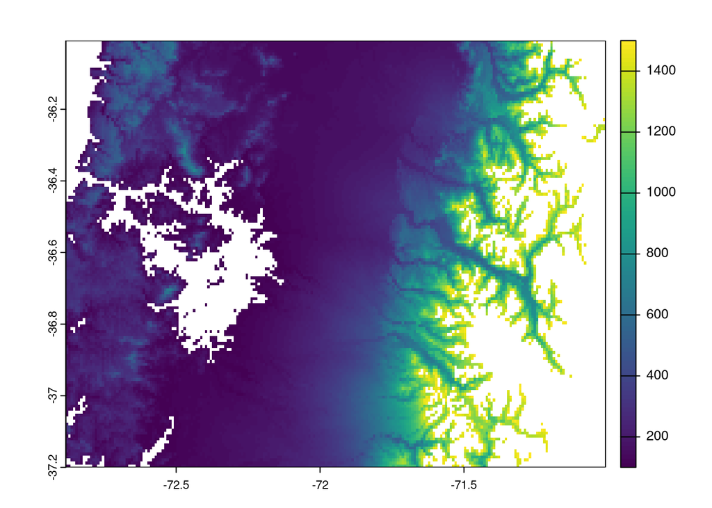

```r
mask_dem <- dem_m
mask_dem[mask_dem < 100 | mask_dem > 1500] <- NA
plot(mask_dem)
```

5. Aplique la mascara anterior a los raster resultantes del ejercicio 3 de precipitación y temperatura.

**Código**

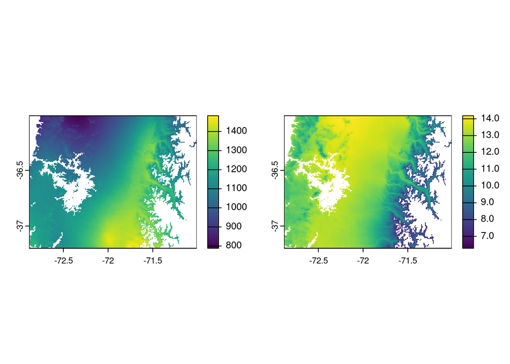

```r
pre_acu_mask <- mask(pre_acu,mask_dem)
temp_avg_mask <- mask(temp_avg,mask_dem)
par(mfrow = c(1,2))
plot(pre_acu_mask)
plot(temp_avg_mask)
```

6. Respecto al rastre de temperatura de la pregunta anterior. ¿Cuál es la temperatura máxima, promedio y mínima para la superficie que se encuentra entre los 100 y los 1500m de elevación? Escriba el script en R para solucionarlo.

**Código**

```r
global(temp_avg_mask,'mean',na.rm = TRUE)
```

```
         mean
mean 12.14328
```

**Código**

```r
global(temp_avg_mask,'min',na.rm = TRUE)
```

```
          min
mean 6.291667
```

**Código**

```r
global(temp_avg_mask,'max',na.rm = TRUE)
```

```
          max
mean 14.18333
```

7. Cree un raster en que la precipitación (resultante de la pregunta 5) este reclasificada de acuerdo a los cuartiles (0-25%,25-50%,50-75%,75-100%).

**Código**

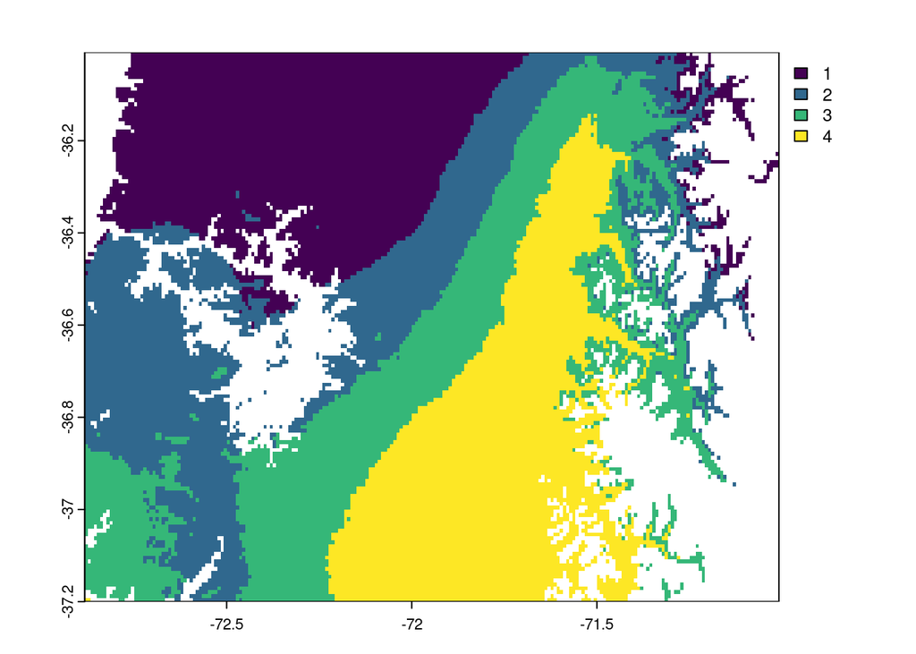

```r
q <- quantile(values(pre_acu_mask),na.rm = TRUE)
recl <- matrix(c(787,1054,1,1054,1156,2,1156,1265,3,1256,1483,4),ncol = 3,byrow = TRUE)
pre_acu_recl <- classify(pre_acu_mask,recl)
plot(pre_acu_recl)
```

8. Cree un nuevo raster como mascara definido por la extensión:
- longitud entre `72°53' 4"O` y `71°0'26"O`
- latitudes `36° 11' 51"S` y `35° 0' 20"`

**Código**

```r
rmask2 <- rast(xmin = -72.88441,ymin=-36-11/60-51/3600,xmax=-71.00730,ymax=-35-20/3600)
```

Aplique la mascara al raster de elevación

**Código**

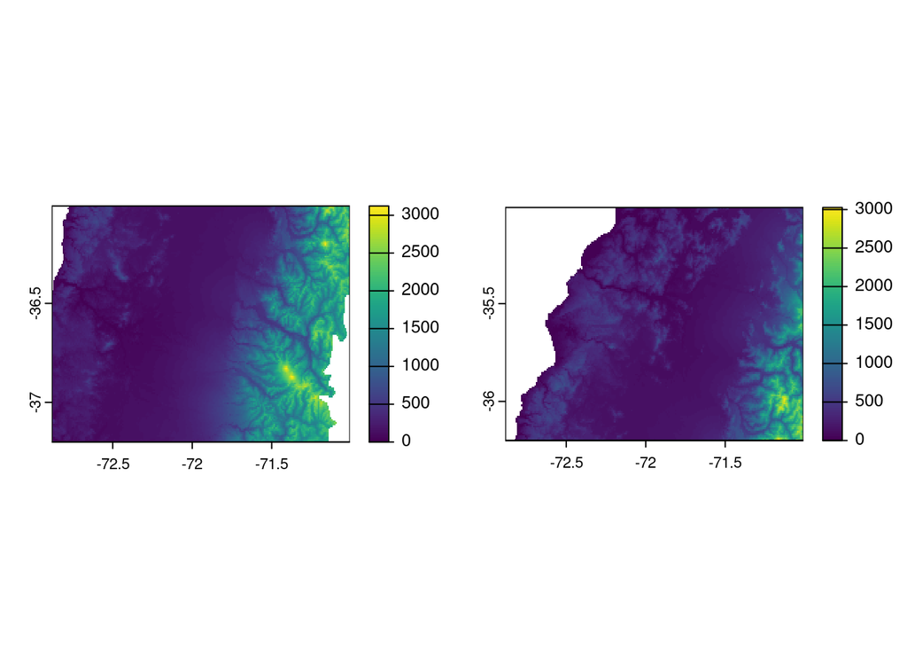

```r
dem_m2 <- crop(dem,rmask2)
par(mfrow =c(1,2))
plot(dem_m)
plot(dem_m2)
```

9. Una los dos raster de elevación enmascarados, el del ejercicio anterior con el del ejercicio 2, en un solo raster. Utilice las funciones `merge` y `mosaic`.

**Código**

```r
dem_merge <- merge(dem_m,dem_m2)
dem_mosaic <- mosaic(dem_m,dem_m2)
```

```
ext 0: -72.8833 -71.0083 -37.2 -35.0083
ext 1: -72.8833 -71.0083 -36.2 -35.0083
```

**Código**

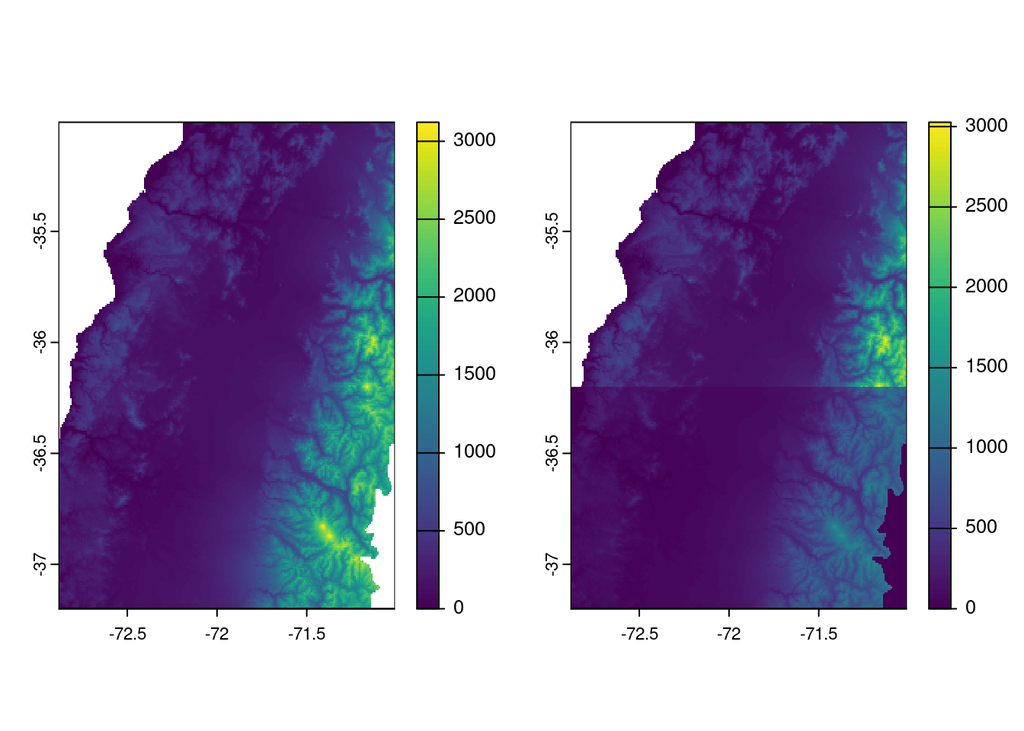

```r
dem_mosaic[dem_mosaic < 0] <- NA
par(mfrow = c(1,2))
plot(dem_merge)
plot(dem_mosaic)
```